# Course 2 - Assigment 4

## Testing a Potential Moderator.

```python
%matplotlib inline
import pandas as pd
import numpy as np
import matplotlib.pyplot as plt
import seaborn as sns
import warnings
import scipy.stats
warnings.filterwarnings('ignore')
import statsmodels.formula.api as smf
import statsmodels.stats.multicomp as multi
```

```python
data = pd.read_csv("../e.csv", low_memory=False)
```

# Codes

## S2AQ5B - How often drank beer last 12 months

- 1: Every day
- 2: Nearly every day
- 3: 3 to 4 times a week
- 4: 2 times a week
- 5: Once a week
- 6: 2 to 3 times a month
- 7: Once a month
- 8: 7 to 11 times in the last year
- 9: 3 to 6 times in the last year
- 10: 1 or 2 times in the last year
- 99: Unknown
- BL: NA, did not drink or unknown if drank beer in last 12 months

## S2BQ2E - Number of episodes of alcohol dependence

- 1-98: Number of episodes
- 99: Unknown
- BL: NA, lifetime abstainer; did not meet symptom and/or duration criteria for lifetime alcohol dependence

## S2DQ1 - Blood/natural Father ever an alcoholic or problem drinker

- 1: Yes
- 2: No
- 9: Unknown

## S2DQ2 - Blood/natural Mother ever an alcoholic or problem drinker

- 1: Yes
- 2: No
- 9: Unknown

## S2AQ5D - Number of beers usually consumed on days when drank beer in last 12 months

- 1-42: Number of beers
- 99: Unknown
- BL: NA

## What we'll do?

Explanatory: Frequency group (S2AQ5B, turned into two categories only) Response: Number of dependence episodes (S2BQ2E) Moderator: Dependent Parent (S2DQ1 and S2DQ2 combined)

Run the ANOVA test for w/ and w/o dependent parent.

```
Number of NAs in S2AQ5B 0
Number of NAs in S2DQ1  0
Number of NAs in S2DQ2  0
Count list for our new variable Alcohol Profile last 12 monts!
2    1378
1    1833
Name: alcohol_profile_12m, dtype: int64
```

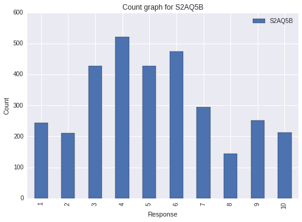

```
Count list for Dependent Parent:
0    1957
1    1254
Name: dependent_parent, dtype: int64
Seans for Dependences Episodes by Freq High vs. Freq Low
                       S2BQ2E
alcohol_profile_12m
1                    2.301146
2                    1.887518
Standard deviation for Dependences Episodes by Freq High vs. Freq Low
                       S2BQ2E
alcohol_profile_12m
1                    6.487297
2                    3.901991
Association between drinking frequency and number of dependence episodes for those without dependent parents
                            OLS Regression Results
==============================================================================
Dep. Variable:                 S2BQ2E   R-squared:                       0.002
Model:                            OLS   Adj. R-squared:                  0.001
Method:                 Least Squares   F-statistic:                     3.689
Date:                Wed, 25 May 2016   Prob (F-statistic):             0.0549
Time:                        05:57:14   Log-Likelihood:                -5952.5
No. Observations:                1957   AIC:                         1.191e+04
Df Residuals:                    1955   BIC:                         1.192e+04
Df Model:                           1
Covariance Type:            nonrobust
===============================================================================================
                                  coef    std err          t      P>|t|      [95.0% Conf. Int.]
-----------------------------------------------------------------------------------------------
Intercept                       2.2199      0.151     14.707      0.000         1.924     2.516
C(alcohol_profile_12m)[T.2]    -0.4454      0.232     -1.921      0.055        -0.900     0.009
==============================================================================
Omnibus:                     3564.447   Durbin-Watson:                   1.993
Prob(Omnibus):                  0.000   Jarque-Bera (JB):          3870419.953
Skew:                          13.098   Prob(JB):                         0.00
Kurtosis:                     219.285   Cond. No.                         2.48
==============================================================================

Warnings:
[1] Standard Errors assume that the covariance matrix of the errors is correctly specified.
```

[output cut: 21 more lines]

```
Kurtosis:                     186.834   Cond. No.                         2.50
==============================================================================

Warnings:
[1] Standard Errors assume that the covariance matrix of the errors is correctly specified.
Dependence episodes by Freq High vs. Low  for without dependent parents
                       S2BQ2E
alcohol_profile_12m
1                    2.219858
2                    1.774427
Dependence episodes by Freq High vs. Low  for with dependent parents
                       S2BQ2E
alcohol_profile_12m
1                    2.431206
2                    2.058288
```

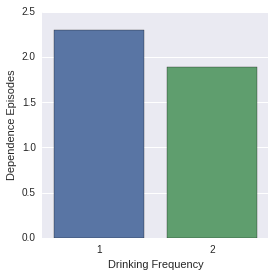

```python
#We don't have NA data
print "Number of NAs in S2AQ5B",
print len(data["S2AQ5D"][data["S2AQ5B"].isnull()])
print "Number of NAs in S2DQ1 ",
print len(data["S2AQ5B"][data["S2DQ1"].isnull()])
print "Number of NAs in S2DQ2 ",
print len(data["S2AQ5B"][data["S2DQ2"].isnull()])

#Discarding the 99 and BL cases
#The BL is displayed as " "
#And unknown cases

sub_data = data[:][(data["S2AQ5B"] != "99") & (data["S2AQ5B"] != " ")]
sub_data = sub_data[:][(sub_data["S2BQ2E"] != "99") & (sub_data["S2BQ2E"] != " ")]
sub_data = sub_data[:][sub_data["S2DQ1"] != 9]
sub_data = sub_data[:][sub_data["S2DQ2"] != 9]
#sub_data = sub_data[:][(sub_data["S2AQ5B"] != 99 & sub_data["S2AQ5B"] != " ")]
sub_data["S2AQ5B"] = sub_data["S2AQ5B"].convert_objects(convert_numeric=True)
sub_data["S2BQ2E"] = sub_data["S2BQ2E"].convert_objects(convert_numeric=True)

print "********************************************************************"
sub_data["alcohol_profile_12m"] = sub_data["S2AQ5B"].apply(lambda x : 1 if int(x) < 6 else 2)
print "Count list for our new variable Alcohol Profile last 12 monts!"
print sub_data["alcohol_profile_12m"].value_counts(sort=False)
print "********************************************************************"
bar = pd.DataFrame(sub_data["S2AQ5B"].convert_objects(convert_numeric=True).value_counts())
bar = bar.sort()
ax = bar.plot(kind='bar')
plt.ylabel("Count")
plt.xlabel("Response")
plt.title('Count graph for S2AQ5B')
plt.show()
print "********************************************************************"
#Create new variable
sub_data["dependent_parent"] = sub_data.apply(lambda x: 1 if x["S2DQ1"]==1 or x["S2DQ2"]==1 else 0 , axis = 1)
print "Count list for Dependent Parent: "
print sub_data["dependent_parent"].value_counts(sort=False)
print "********************************************************************"

print ("Seans for Dependences Episodes by Freq High vs. Freq Low")
m1= sub_data[["S2BQ2E", "alcohol_profile_12m"]].groupby('alcohol_profile_12m').mean()
print (m1)
print "********************************************************************"
print ("Standard deviation for Dependences Episodes by Freq High vs. Freq Low")
st1= sub_data[["S2BQ2E", "alcohol_profile_12m"]].groupby('alcohol_profile_12m').std()
print (st1)
print "********************************************************************"

# bivariate bar graph
sns.factorplot(x="alcohol_profile_12m", y="S2BQ2E", data=sub_data, kind="bar", ci=None)
plt.xlabel('Drinking Frequency')
plt.ylabel('Dependence Episodes')
print "********************************************************************"

sub_data2=sub_data[(sub_data['dependent_parent']== 0)]
sub_data3=sub_data[(sub_data['dependent_parent']== 1)]

print ('Association between drinking frequency and number of dependence episodes for those without dependent parents')
model2 = smf.ols(formula='S2BQ2E ~ C(alcohol_profile_12m)', data=sub_data2).fit()
print (model2.summary())
print "********************************************************************"
print ('Association between drinking frequency and number of dependence episodes for those with dependent parents')
model3 = smf.ols(formula='S2BQ2E ~ C(alcohol_profile_12m)', data=sub_data3).fit()
print (model3.summary())
print "********************************************************************"
print ("Dependence episodes by Freq High vs. Low  for without dependent parents")
m3= sub_data2[["S2BQ2E", "alcohol_profile_12m"]].groupby('alcohol_profile_12m').mean()
print (m3)
print "********************************************************************"
print ("Dependence episodes by Freq High vs. Low  for with dependent parents")
m4 = sub_data3[["S2BQ2E", "alcohol_profile_12m"]].groupby('alcohol_profile_12m').mean()
print (m4)
```

# Conclusion

First case: **Association between drinking frequency and number of dependence episodes for those without dependent parents** Our result is almost rejecting H0, the p-value is 0.055. It'd represent that there are difference between the mean number of dependence episodes for those with high drinking frequency. But we'll not reject H0.

Second case: **Association between drinking frequency and number of dependence episodes for those with dependent parents** Here que H0 can't be rejected at all. High p-value. So, we'd say that the parents dependence isn't a Moderator, because the two different groups accept the null hypothesis (though it almost wasn't the case with the p-value of 0.055 in the first case).

```
'0.16.2'
```